# SKOV3 cell counts

Leander Meuris

2025-10-14

# Data

The data are from a flow cytometry experiment which analyzed the number of CART cells in the blood or spleen of mice carrying a tumor and treated with different versions of CAR T-cells or controls. The following variables are in the dataset:

- Experiment: from which experiment are the data (Exp 30, 32, 43)
- Timepoint: from which moment in the experiment? We have “Early”, “Mid” and “Late”, corresponding to day 34, 80/88/85 (Exp 30, 32, 43) and 116/123/123 (Exp 30, 32 ,43).
- Treatment: mice received no CAR T-cells (PBS, NTC, None), CAR T-cells but no MGAT5 engineering (CD70 nanoCAR-neg and CD70 nanoCAR-WT) or CAR T-cells which were MGAT5 KO (CD70 nanoCAR-MGAT5 KO)
- CellCount: the number of cells found in a spleen or in 1 ul blood.
- Location: whether spleen or blood was analyzed.

```r
data <- read_xlsx(here('data/FACSdata_clean_new.xlsx'))
```

Make a group variable, indicating no CAR, CAR or CAR with MGAT5 KO. Then make 6 subsets of the data: Spleen and Blood, each early, mid, late.

```r
data <- data %>%
  filter(!is.na(CellCount))

Early_TP <- c(34)
Mid_TP <- c(80, 88, 85)
End_TP <- c(116, 123)

data <- data %>%
  mutate(Experiment = paste0('Exp', Experiment),
         Day_Meas_Early = 34,
         Day_Meas_Mid = case_when(
           Experiment == 'Exp30' ~ 80,
           Experiment == 'Exp32' ~ 88,
           Experiment == 'Exp43' ~ 85),
         Day_Meas_End = case_when(
           Experiment == 'Exp30' ~ 116,
           Experiment %in% c('Exp32', 'Exp43') ~ 123),
         TimePoint = case_when(
           Day %in% Early_TP ~ 'Early',
           Day %in% Mid_TP ~ 'Mid',
           Day %in% End_TP ~ 'Late'),
         Group = factor(case_when(
           Treatment %in% c('PBS', 'NTC', 'None') ~ 'Control',
           Treatment %in% c('CD70 nanoCAR-neg', 'CD70 nanoCAR-WT') ~ 'CAR',
           Treatment %in% c('CD70 nanoCAR-MGAT5 KO','CD70 nanoCAR-MGAT5KO') ~ 'MGAT5KO_CAR'),
           levels = c('Control', 'CAR', 'MGAT5KO_CAR'),
           labels = c('WT T-cells or None', 'CD70 nanoCAR', 'CD70 nanoCAR - MGAT5 KO')),
         TimePoint = factor(TimePoint,
                            levels = c('Early', 'Mid', 'Late'),
                            labels = c('Early', 'Mid', 'Endpoint')),
         ID = paste0(Experiment,'M', Mouse),
         Experiment = factor(Experiment,
                             levels = c('Exp30', 'Exp32', 'Exp43'),
                             labels = c('Experiment A', 'Experiment B', 'Experiment C')),
         Location = factor(Location),
         plCC = pseudo_log(CellCount))
```

We note that cell counts can be lower than 1 if we look in blood. For cell counts we would like to use a Poisson or Negative binomial model, however, these don’t work well with non-integers. So we will work with the number of cells per ml blood and round to the nearest integer.

For spleens, we don’t have counts below 1, so there we just round to the nearest integer.

```r
data <- data %>%
  mutate(CellCount = ifelse(Location == 'Blood',
                            (1000*CellCount) %>% round(., 0),
                            CellCount %>% round(., 0)))
```

We also want to add the info on which mice are tumor free or have a tumor at the different moments of measurement.

```r
Ctrl <- read_xlsx(here('data/Survival.xlsx')) %>%
  mutate(ID = paste0('Exp',Experiment,'M',Mouse),
         Experiment = factor(paste0('Exp', Experiment),
                             levels = c('Exp30', 'Exp32', 'Exp43'),
                             labels = c('Experiment A', 'Experiment B', 'Experiment C')))

data <- left_join(data, Ctrl)
```

We first determine the last day of any measurement for each mouse

```r
data <- left_join(data, data %>%
                    group_by(ID) %>%
                    summarise(max_time = max(pmax(
                      Day, TimeFUP_FullCtrl, TimeFUP_PartialCtrl,
                      TimeFUS_FullCtrl, TimeFUS_PartialCtrl,
                      DayRelapse, Daylastmeasurement,na.rm = T),
                      na.rm = T), .groups = 'drop'))
```

We define classes of outcome by the mid or end timepoint. - mouse dead before - tumor growing - tumor stasis/shrinking - tumor free

First for the mid timepoint

```r
data <- data %>%
  mutate(Status_Mid = case_when(
    # Control mice and special case Exp A
    is.na(StatusPrimary) ~ NA,
    Experiment == 'Experiment A' &
      StatusPrimary == 'No control' ~ 'Tumor',
    Experiment == 'Experiment A' &
      StatusPrimary == 'Control, no relapse' ~ 'No tumor',
    # Mouse died before measurement
    Day_Meas_Mid > max_time &
      Experiment %in% c('Experiment B', 'Experiment C') ~ 'Dead',
    # Mouse never controlled tumor
    Day_Meas_Mid <= max_time &
      StatusPrimary == 'No control' ~ 'Tumor',
    # Mouse partially controlled tumor, then relapse
    Day_Meas_Mid <= max_time &
      StatusPrimary == 'Partial control, relapse' &
      Day_Meas_Mid < TimeFUP_PartialCtrl ~ 'Tumor',
    Day_Meas_Mid <= max_time &
      StatusPrimary == 'Partial control, relapse' &
      between(Day_Meas_Mid, TimeFUP_PartialCtrl, DayRelapse) ~ 'Tumor',
    Day_Meas_Mid <= max_time &
      StatusPrimary == 'Partial control, relapse' &
      DayRelapse < Day_Meas_Mid ~ 'Tumor',
    # Mouse fully controlled tumor, then relapse
    Day_Meas_Mid <= max_time &
      StatusPrimary == 'Control, relapse' &
      Day_Meas_Mid < TimeFUP_FullCtrl ~ 'Tumor',
    Day_Meas_Mid <= max_time &
      StatusPrimary == 'Control, relapse' &
      between(Day_Meas_Mid, TimeFUP_FullCtrl, DayRelapse) ~ 'No tumor',
    Day_Meas_Mid <= max_time &
      StatusPrimary == 'Control, relapse' &
      DayRelapse < Day_Meas_Mid ~ 'Tumor',
    # Mouse fully controlled tumor, never relapsed
    Day_Meas_Mid <= max_time &
      StatusPrimary == 'Control, no relapse' &
      Day_Meas_Mid < TimeFUP_PartialCtrl ~ 'Tumor',
    Day_Meas_Mid <= max_time &
      StatusPrimary == 'Control, no relapse' &
      Day_Meas_Mid >= TimeFUP_PartialCtrl ~ 'No tumor',
    ))

data <- data %>%
  mutate(Status_Mid = factor(Status_Mid,
                             levels = c('No tumor', 'Tumor', 'Dead')))
```

Then for the end timepoint

```r
data <- data %>%
  mutate(Status_End = case_when(
    Experiment == 'Experiment A' &
      max_time == 34 ~ 'No tumor',
    # Mouse died before measurement
    Day_Meas_End > max_time ~ 'Dead',
    # Exp A, all mice cleared the tumor
    Day_Meas_End <= max_time &
      Experiment == 'Experiment A' ~ 'No tumor',
    # Mouse never or only partially controlled tumor
    Day_Meas_End <= max_time &
      StatusSecondary %in% c('No control', 'Partial control') ~ 'Tumor',
    # Mouse fully controlled the tumor
    Day_Meas_End <= max_time &
      StatusSecondary == 'Control' ~ 'No tumor',
    # Mouse never developed a tumor
    Day_Meas_End <= max_time &
      StatusSecondary == 'No tumor' ~ 'No tumor'
    ))

data <- data %>%
  mutate(Status_End = factor(Status_End,
                             levels = c('No tumor', 'Tumor', 'Dead')))
```

Disease course

```r
data <- data %>%
  mutate(T1_to_T3 = paste0('Tumor - ', Status_Mid, ' - ', Status_End),
         T1_to_T2 = paste0('Tumor - ', Status_Mid),
         T2_to_T3 = paste0(Status_Mid, ' - ', Status_End))
```

# Exploratory data analysis

Plot the data by experiment and timepoint. First for blood data, then for spleen data. We also use a pseudo-log-scale y axis to better see differences. (A pseudo log-scale uses a log scale for large values but gradually becomes a linear scale for small values)

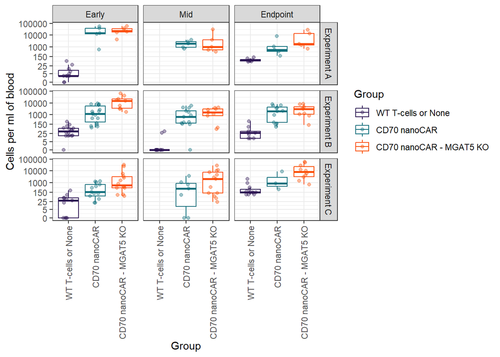

```r
BloodBoxplots <- data %>%
  filter(Location == 'Blood') %>%
  ggplot(aes(x = Group, y = CellCount, color = Group)) +
  geom_boxplot(outlier.shape = NA) +
  geom_jitter(alpha = 0.4, width = 0.2) +
  facet_grid(Experiment~TimePoint) +
  scale_y_continuous(trans = 'pseudo_log',
                     breaks = c(0,5,25,150,1000,10000,100000)) +
  scale_x_discrete(guide = guide_axis(angle = 90)) +
  theme_bw() +
  scale_colour_manual(values = c(
    rgb(44,20,83, maxColorValue = 255),
    rgb(14,111,124, maxColorValue = 255),
    rgb(251,79,6, maxColorValue = 255))) +
  labs(y = 'Cells per ml of blood')

SpleenBoxplots <- data %>%
  filter(Location == 'Spleen') %>%
  ggplot(aes(x = Group, y = CellCount, color = Group)) +
  geom_boxplot(outlier.shape = NA) +
  geom_jitter(alpha = 0.4, width = 0.2) +
  facet_grid(Experiment~TimePoint) +
  scale_y_continuous(trans = 'pseudo_log',
                     breaks = c(0,5,25,150,1000,10000,100000)) +
  scale_x_discrete(guide = guide_axis(angle = 90)) +
  theme_bw() +
  scale_colour_manual(values = c(
    rgb(44,20,83, maxColorValue = 255),
    rgb(14,111,124, maxColorValue = 255),
    rgb(251,79,6, maxColorValue = 255))) +
  labs(y = 'Cells per Spleen')

#ggsave(here("output/BloodBoxplots.pdf"), BloodBoxplots,
#       device = "pdf", height = 8, width = 8, dpi=600)
#ggsave(here("output/SpleenBoxplots.pdf"), SpleenBoxplots,
#       device = "pdf", height = 8, width = 8, dpi=600)

BloodBoxplots
```

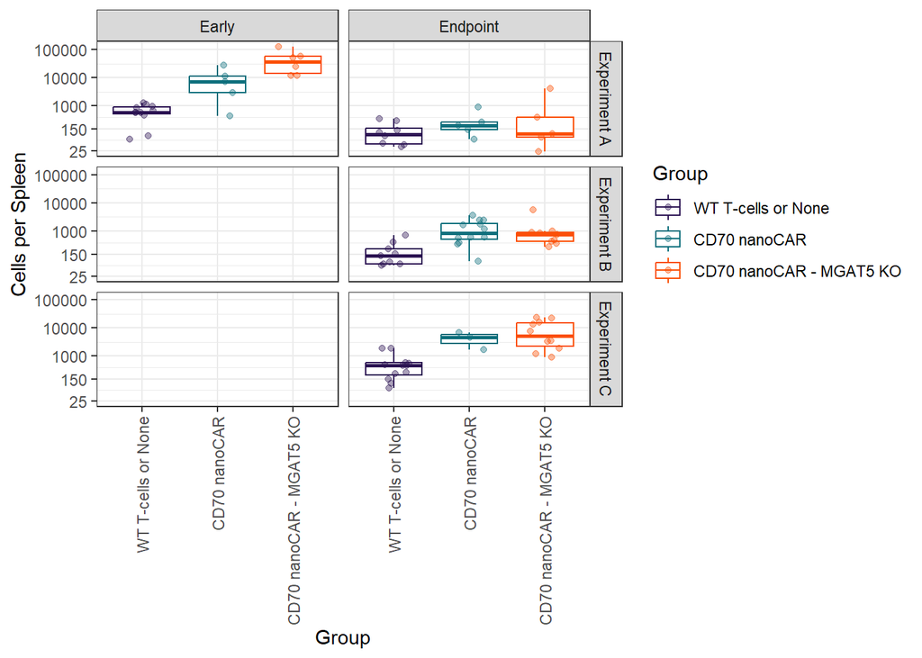

```r
SpleenBoxplots
```

# Models comparing MGAT5 vs WT per timepoint

## Model

Summary: - Model separately per experiment and per timepoint - Don’t take into account which mice cleared the tumor

```r
modeldata <- data %>%
  group_by(Location, TimePoint, Experiment) %>%
  nest()
```

Run models and output results of contrasts

```r
# Running the models
modeldata <- modeldata %>%
  rowwise() %>%
  mutate(mod = list(glm(CellCount ~ Group, data = data, family = quasipoisson)),
         summ = list(summary(mod)),
         Omnibus = list(car::Anova(mod, type = 2)),
         Coefnames = list(names(coef(mod))),
         ContMat = list(
           matrix((-1)*((str_detect(Coefnames, 'nanoCAR') %>% as.numeric) -
                    (2*(str_detect(Coefnames, 'MGAT5') %>% as.numeric))),
                               nrow = 1,
                               ncol = length(Coefnames),
                               dimnames = list('MGAT5 vs nanoCAR WT',
                                               Coefnames))),
         data = list(data %>% mutate(
           pred = predict(mod, type = 'response'))),
         Table = list(left_join(
           multcomp::glht(mod, linfct = ContMat) %>% summary %>% tidy,
           multcomp::glht(mod, linfct = ContMat) %>% confint %>% tidy) %>%
             mutate(`Adj. p-value` = ifelse(
               adj.p.value < 0.001, "<0.001", round(adj.p.value, 3)) %>% as.character) %>%
             mutate(across(where(is.numeric)) %>% exp(.) %>% round(., 2)) %>%
             select(-null.value) %>%
             select(contrast, estimate,`95% CI, lower` = conf.low, `95% CI, upper` = conf.high,`Adj. p-value`)))

knitr::kable(modeldata %>%
               unnest(Table) %>%
               select(Experiment, TimePoint, contrast, estimate, `95% CI, lower`, `95% CI, upper`, `Adj. p-value`) %>%
               arrange(TimePoint, Experiment))
```

| Location | Experiment | TimePoint | contrast | estimate | 95% CI, lower | 95% CI, upper | Adj. p-value |
| --- | --- | --- | --- | --- | --- | --- | --- |
| Blood | Experiment A | Early | MGAT5 vs nanoCAR WT | 1.14 | 0.60 | 2.17 | 0.684 |
| Spleen | Experiment A | Early | MGAT5 vs nanoCAR WT | 4.83 | 1.64 | 14.26 | 0.004 |
| Blood | Experiment B | Early | MGAT5 vs nanoCAR WT | 7.21 | 3.23 | 16.13 | <0.001 |
| Blood | Experiment C | Early | MGAT5 vs nanoCAR WT | 11.95 | 1.14 | 125.56 | 0.039 |
| Blood | Experiment A | Mid | MGAT5 vs nanoCAR WT | 3.66 | 0.31 | 42.69 | 0.301 |
| Blood | Experiment B | Mid | MGAT5 vs nanoCAR WT | 1.24 | 0.61 | 2.52 | 0.549 |
| Blood | Experiment C | Mid | MGAT5 vs nanoCAR WT | 6.41 | 0.51 | 81.13 | 0.151 |
| Blood | Experiment A | Endpoint | MGAT5 vs nanoCAR WT | 4.50 | 0.90 | 22.55 | 0.067 |
| Spleen | Experiment A | Endpoint | MGAT5 vs nanoCAR WT | 2.96 | 0.47 | 18.51 | 0.246 |
| Blood | Experiment B | Endpoint | MGAT5 vs nanoCAR WT | 1.26 | 0.64 | 2.49 | 0.504 |
| Spleen | Experiment B | Endpoint | MGAT5 vs nanoCAR WT | 0.90 | 0.39 | 2.07 | 0.811 |
| Blood | Experiment C | Endpoint | MGAT5 vs nanoCAR WT | 5.22 | 0.60 | 45.41 | 0.135 |
| Spleen | Experiment C | Endpoint | MGAT5 vs nanoCAR WT | 2.15 | 0.69 | 6.70 | 0.188 |

## Data plots

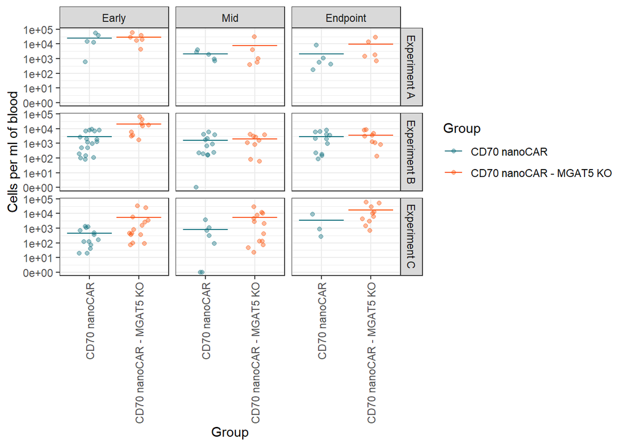

```r
modeldata$ID <- 1:nrow(modeldata)

data_aug <- bind_rows(modeldata$data, .id = "ID") %>%
  mutate(ID = as.numeric(ID))

data_aug <- left_join(data_aug, modeldata %>% select(ID, Experiment, Location, TimePoint))

BloodPlots <- data_aug %>%
  filter(Location == 'Blood') %>%
  filter(Group != 'WT T-cells or None') %>%
  ggplot(aes(x = Group, y = CellCount, color = Group)) +
  geom_errorbar(aes(y = pred, color = Group, ymin = pred, ymax = pred)) +
  geom_jitter(alpha = 0.4, width = 0.2) +
  facet_grid(Experiment~TimePoint) +
  scale_y_continuous(trans = 'pseudo_log',
                     breaks = c(0,10,100,1000,10000,100000)) +
  scale_x_discrete(guide = guide_axis(angle = 90)) +
  theme_bw() +
  scale_colour_manual(values = c(
    #rgb(44,20,83, maxColorValue = 255),
    rgb(14,111,124, maxColorValue = 255),
    rgb(251,79,6, maxColorValue = 255))) +
  labs(y = 'Cells per ml of blood')

BloodPlots
```

```r
ggsave(here("output/BloodPlots.pdf"), BloodPlots,
       device = "pdf", height = 8, width = 8, dpi=600)
```

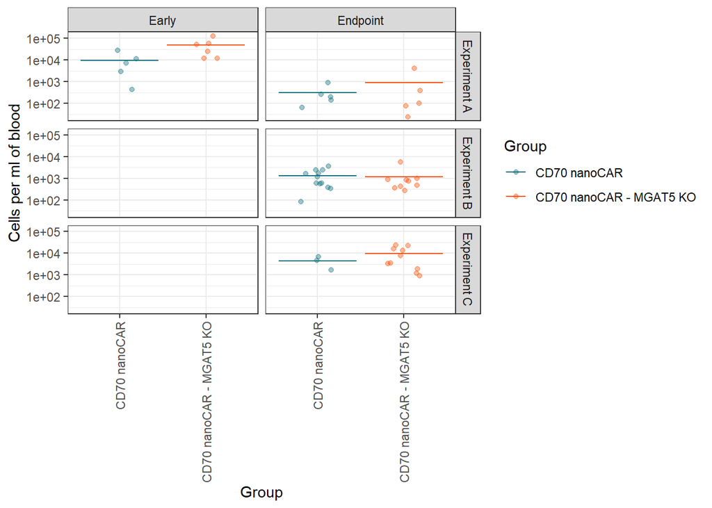

```r
SpleenPlots <- data_aug %>%
  filter(Location == 'Spleen') %>%
  filter(Group != 'WT T-cells or None') %>%
  ggplot(aes(x = Group, y = CellCount, color = Group)) +
  geom_errorbar(aes(y = pred, color = Group, ymin = pred, ymax = pred)) +
  geom_jitter(alpha = 0.4, width = 0.2) +
  facet_grid(Experiment~TimePoint) +
  scale_y_continuous(trans = 'pseudo_log',
                     breaks = c(0,10,100,1000,10000,100000)) +
  scale_x_discrete(guide = guide_axis(angle = 90)) +
  theme_bw() +
  scale_colour_manual(values = c(
    #rgb(44,20,83, maxColorValue = 255),
    rgb(14,111,124, maxColorValue = 255),
    rgb(251,79,6, maxColorValue = 255))) +
  labs(y = 'Cells per ml of blood')

SpleenPlots
```

```r
ggsave(here("output/SpleenPlots.pdf"), SpleenPlots,
       device = "pdf", height = 8, width = 6, dpi=600)
```

Plots are on the log scale, with observed data as dots and model predictions as lines. These lines are the predicted mean of each group. Plotted on the log scale, these tend to look ‘too high’, especially with right skew data, but are actually correct log transformed means. On the original scale they would look like correct means.

## Methods

To analyse the FACS-based cell-count data of three separate experiments, we ran separate models for each combination of time-point (Early, Mid, Late/Endpoint), source (Blood or Spleen) and donor (= experiment). We don’t have data available for all combinations of factors: for Blood, data is lacking on non-engineered cells for the Mid timepoint in experiment A and C. For Spleen we don’t have any data for the Mid timepoint and we only have data from experiment A for the Early timepoint. Consequently, no models were run for these settings.

We ran quasipoisson models in R [ref], using the glm function with Cell Counts as the outcome variable and Group as predictor. An omnibus test for the main effects was performed using the Anova function (car package [ref]) with type 2 sums of squares. Next, we tested the specific contrast of MGAT5 engineered anti-CD70 nanoCAR T cells versus WT nanoCAR T cells. The contrast estimates, p-values and 95% confidence intervals were calculated using the multcomp package [ref].

# Population contraction/expansion: TP1 -> TP2 and MGAT5 effect from one model

To answer this, we will look separately at the mice that have cleared the tumor vs. those that have not. We made a new variable for this (Status_Mid), based on the survival analysis. This variable captures whether a mouse has died, survived and carries a tumor at TimePoint 2 or survived and does not carry a tumor by timepoint 2.

A complication is that in experiment A the mice for which blood cell counts are available at the early time point were all sacrificed to count splenocytes. So in experiment A we do not have measurements on multiple time points for the same mice. The setup of experiment B and C was such that we do have multiple time points on the same mice (i.e. correlated data).

## Model

Prepare data for modeling

```r
modeldata <- data %>%
  filter(Location == 'Blood') %>%
  filter(TimePoint != 'Endpoint') %>%
  filter(Group != 'WT T-cells or None') %>%
  filter(Status_Mid != 'Dead') %>%
  droplevels

mdata <- modeldata %>%
  group_by(TimePoint, Status_Mid, Group, Experiment) %>%
  summarise(mCellCount = mean(CellCount, na.rm = TRUE))

modeldata <- left_join(modeldata, mdata)
```

Run model

```r
mod <- glmmTMB(CellCount ~ TimePoint*Status_Mid*Group + Experiment*(TimePoint + Status_Mid + Group) + (1|ID),
              data = modeldata, family = nbinom2)

# glmmTMB::diagnose(mod)
# resids <- DHARMa::simulateResiduals(mod)
# plot(resids)
```

Model predictions

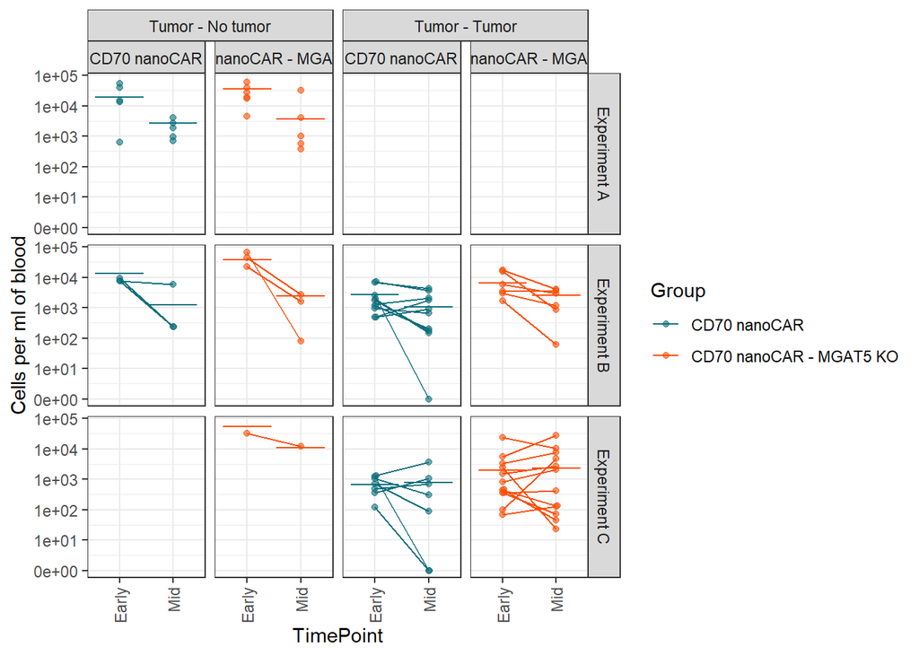

```r
modeldata$pred <- predict(mod, type = 'response', re.form = NA)

T1_to_T2 <- modeldata %>%
  ggplot(aes(x = TimePoint, y = CellCount, color = Group)) +
  geom_errorbar(aes(y = pred, ymin = pred, ymax = pred)) +
  #geom_errorbar(aes(y = mCellCount, ymin = mCellCount, ymax = mCellCount, color = Group)) +
  geom_beeswarm(alpha = 0.6) +
  geom_line(aes(group = ID, color = Group)) +
  ggh4x::facet_nested(Experiment ~ T1_to_T2 + Group) +
  scale_y_continuous(trans = 'pseudo_log', breaks = c(0, 10, 100, 1000, 10000, 100000)) +
  scale_x_discrete(guide = guide_axis(angle = 90)) +
  theme_bw() +
  scale_colour_manual(values = c(
    #rgb(44,20,83, maxColorValue = 255),
    rgb(14,111,124, maxColorValue = 255),
    rgb(251,79,6, maxColorValue = 255))) +
  labs(y = 'Cells per ml of blood')

ggsave(here("output/T1_to_T2.pdf"), T1_to_T2,
       device = "pdf",  height = 8, width = 10, dpi=600)

T1_to_T2
```

Plots are on the log scale, with observed data as dots and model predictions as lines. These lines are the predicted mean of each group. Plotted on the log scale, these tend to look ‘too high’, especially with right skew data, but are actually correct log transformed means. On the original scale they would look like correct means.

## Contrasts

Output results of contrasts, first without multiple testing adjustment. This corresponds to what Nico asked (treat results of each experiment as fully independent). I would advise against.

```r
emmA <- emmeans(mod, ~ TimePoint | Group*Status_Mid+Experiment, adjust = 'none',
                at = list(Experiment = 'Experiment A', Status_Mid = 'No tumor'))
ctrA <- pairs(emmA, type = 'response', reverse = TRUE, infer = TRUE, adjust = 'none')

emmB <- emmeans(mod, ~ TimePoint | Group*Status_Mid+Experiment, at = list(Experiment = 'Experiment B'))
ctrB <- pairs(emmB, type = 'response', reverse = TRUE, infer = TRUE, adjust = 'none')

emmC <- emmeans(mod, ~ TimePoint | Group*Status_Mid+Experiment,
                at = list(Experiment = 'Experiment C', Status_Mid = 'Tumor'))
ctrC <- pairs(emmC, type = 'response', reverse = TRUE, infer = TRUE, adjust = 'none')

table_nopadj <- summary(rbind(ctrA, ctrB, ctrC), adjust = 'none')
table_nopadj <- table_nopadj %>% as_tibble %>%
  mutate(`Adj. p-value` = ifelse(p.value < 0.001, "<0.001", round(p.value, 3)) %>% as.character) %>%
  mutate(across(where(is.numeric)) %>% round(., 3)) %>%
  select(-null) %>%
  select(Experiment, Group, Status_Mid,
         contrast,
         `Ratio of Cell Counts` = ratio,
         `95% CI, lower` = asymp.LCL,
         `95% CI, upper` = asymp.UCL,
         `Adj. p-value`)

knitr::kable(table_nopadj)
```

| Experiment | Group | Status_Mid | contrast | Ratio of Cell Counts | 95% CI, lower | 95% CI, upper | Adj. p-value |
| --- | --- | --- | --- | --- | --- | --- | --- |
| Experiment A | CD70 nanoCAR | No tumor | Mid / Early | 0.141 | 0.031 | 0.637 | 0.011 |
| Experiment A | CD70 nanoCAR / MGAT5 KO | No tumor | Mid / Early | 0.103 | 0.023 | 0.469 | 0.003 |
| Experiment B | CD70 nanoCAR | No tumor | Mid / Early | 0.090 | 0.016 | 0.493 | 0.006 |
| Experiment B | CD70 nanoCAR / MGAT5 KO | No tumor | Mid / Early | 0.066 | 0.014 | 0.310 | <0.001 |
| Experiment B | CD70 nanoCAR | Tumor | Mid / Early | 0.391 | 0.153 | 1.003 | 0.051 |
| Experiment B | CD70 nanoCAR / MGAT5 KO | Tumor | Mid / Early | 0.394 | 0.133 | 1.163 | 0.092 |
| Experiment C | CD70 nanoCAR | Tumor | Mid / Early | 1.205 | 0.407 | 3.562 | 0.736 |
| Experiment C | CD70 nanoCAR / MGAT5 KO | Tumor | Mid / Early | 1.213 | 0.497 | 2.959 | 0.672 |

Next: same comparisons but with multiple testing adjustment. I recommend these, since all data are in the same model (with an adjustment for experiment).

```r
table_padj <- summary(rbind(ctrA, ctrB, ctrC), adjust = 'mvt')
table_padj <- table_padj %>% as_tibble %>%
  mutate(`Adj. p-value` = ifelse(p.value < 0.001, "<0.001", round(p.value, 3)) %>% as.character) %>%
  mutate(across(where(is.numeric)) %>% round(., 3)) %>%
  select(-null) %>%
  select(Experiment, Group, Status_Mid,
         contrast,
         `Ratio of Cell Counts` = ratio,
         `95% CI, lower` = asymp.LCL,
         `95% CI, upper` = asymp.UCL,
         `Adj. p-value`)

knitr::kable(table_padj)
```

| Experiment | Group | Status_Mid | contrast | Ratio of Cell Counts | 95% CI, lower | 95% CI, upper | Adj. p-value |
| --- | --- | --- | --- | --- | --- | --- | --- |
| Experiment A | CD70 nanoCAR | No tumor | Mid / Early | 0.141 | 0.017 | 1.135 | 0.079 |
| Experiment A | CD70 nanoCAR / MGAT5 KO | No tumor | Mid / Early | 0.103 | 0.013 | 0.839 | 0.025 |
| Experiment B | CD70 nanoCAR | No tumor | Mid / Early | 0.090 | 0.009 | 0.946 | 0.041 |
| Experiment B | CD70 nanoCAR / MGAT5 KO | No tumor | Mid / Early | 0.066 | 0.008 | 0.561 | 0.005 |
| Experiment B | CD70 nanoCAR | Tumor | Mid / Early | 0.391 | 0.106 | 1.438 | 0.31 |
| Experiment B | CD70 nanoCAR / MGAT5 KO | Tumor | Mid / Early | 0.394 | 0.088 | 1.760 | 0.487 |
| Experiment C | CD70 nanoCAR | Tumor | Mid / Early | 1.205 | 0.269 | 5.395 | 1 |
| Experiment C | CD70 nanoCAR / MGAT5 KO | Tumor | Mid / Early | 1.213 | 0.353 | 4.165 | 0.999 |

# Population contraction/expansion: TP2 -> TP3

To answer this, we will look separately at the mice that have cleared the secondary tumor vs. those that have not. We made a new variable for this (Status_End), based on the survival analysis. This variable captures whether a mouse has died, survived and carries a tumor at TimePoint 3 or survived and does not carry a tumor by timepoint 3.

In this case, we have paired measurements also for experiment A.

We present the data split up by disease course over the 3 timepoints.

```r
modeldata <- data %>%
  filter(Location == 'Blood') %>%
  filter(TimePoint != 'Early') %>%
  filter(Group != 'WT T-cells or None') %>%
  filter(Status_Mid != 'Dead' & Status_End != 'Dead') %>%
  droplevels

mdata <- modeldata %>%
  group_by(TimePoint, Status_End, Group, Experiment) %>%
  summarise(mCellCount = mean(CellCount, na.rm = TRUE))

modeldata <- left_join(modeldata, mdata)
```

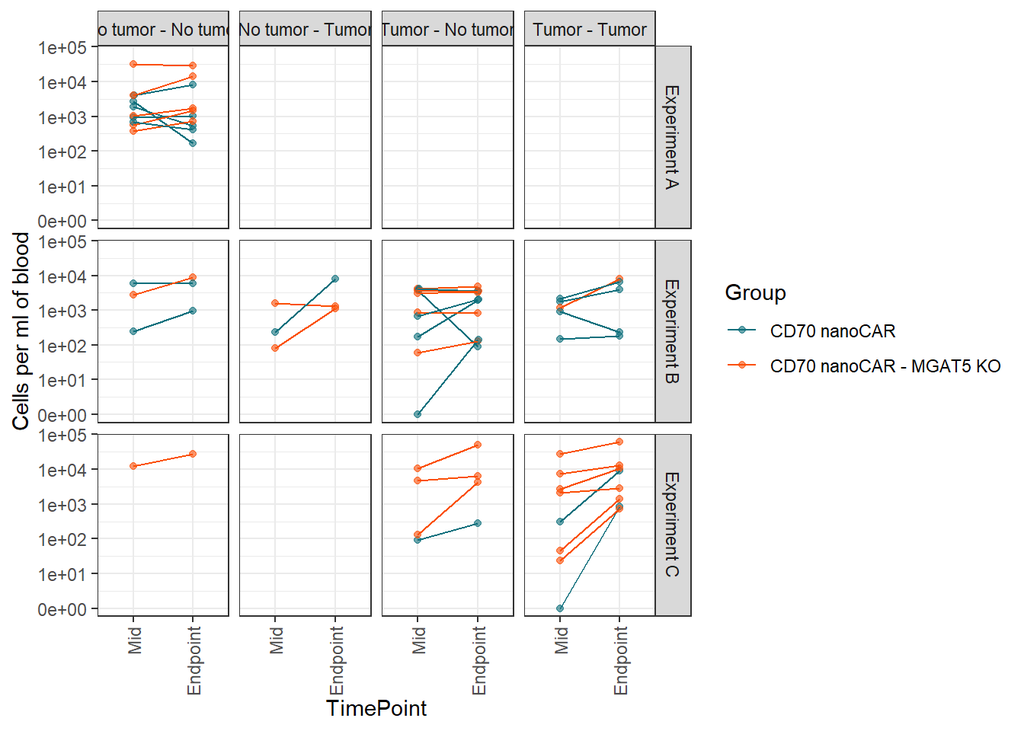

```r
modeldata %>%
  ggplot(aes(x = TimePoint, y = CellCount, color = Group)) +
  #geom_errorbar(aes(y = mCellCount, ymin = mCellCount, ymax = mCellCount)) +
  geom_beeswarm(alpha = 0.6, aes(color = Group)) +
  geom_line(aes(group = ID)) +
  ggh4x::facet_nested(Experiment ~ T2_to_T3) +
  scale_y_continuous(trans = 'pseudo_log', breaks = c(0, 10, 100, 1000, 10000, 100000)) +
  scale_x_discrete(guide = guide_axis(angle = 90)) +
  theme_bw() +
  scale_colour_manual(values = c(
    #rgb(44,20,83, maxColorValue = 255),
    rgb(14,111,124, maxColorValue = 255),
    rgb(251,79,6, maxColorValue = 255))) +
  labs(y = 'Cells per ml of blood')
```

Is it worthwhile analyzing this? There don’t seem to be clear trends as opposed to early to mid…

```r
citation()
```

```
##
##   R Core Team (2024). _R: A Language and Environment for Statistical
##   Computing_. R Foundation for Statistical Computing, Vienna, Austria.
##   <https://www.R-project.org/>.
##
## A BibTeX entry for LaTeX users is
##
##   @Manual{,
##     title = {R: A Language and Environment for Statistical Computing},
##     author = {{R Core Team}},
##     organization = {R Foundation for Statistical Computing},
##     address = {Vienna, Austria},
##     year = {2024},
##     url = {https://www.R-project.org/},
##   }
##
## We have invested a lot of time and effort in creating R, please cite it
## when using it for data analysis. See also 'citation("pkgname")' for
## citing R packages.
```

```r
citation('tidyverse')
```

```
##
##   Wickham H, Averick M, Bryan J, Chang W, McGowan LD, François R,
##   Grolemund G, Hayes A, Henry L, Hester J, Kuhn M, Pedersen TL, Miller
##   E, Bache SM, Müller K, Ooms J, Robinson D, Seidel DP, Spinu V,
##   Takahashi K, Vaughan D, Wilke C, Woo K, Yutani H (2019). "Welcome to
##   the tidyverse." _Journal of Open Source Software_, *4*(43), 1686.
##   doi:10.21105/joss.01686 <https://doi.org/10.21105/joss.01686>.
##
## A BibTeX entry for LaTeX users is
##
##   @Article{,
##     title = {Welcome to the {tidyverse}},
##     author = {Hadley Wickham and Mara Averick and Jennifer Bryan and Winston Chang and Lucy D'Agostino McGowan and Romain François and Garrett Grolemund and Alex Hayes and Lionel Henry and Jim Hester and Max Kuhn and Thomas Lin Pedersen and Evan Miller and Stephan Milton Bache and Kirill Müller a…
##     year = {2019},
##     journal = {Journal of Open Source Software},
##     volume = {4},
##     number = {43},
##     pages = {1686},
##     doi = {10.21105/joss.01686},
##   }
```

```r
citation('glmmTMB')
```

```
##
##   Mollie E. Brooks, Kasper Kristensen, Koen J. van Benthem, Arni
##   Magnusson, Casper W. Berg, Anders Nielsen, Hans J. Skaug, Martin
##   Maechler and Benjamin M. Bolker (2017). glmmTMB Balances Speed and
##   Flexibility Among Packages for Zero-inflated Generalized Linear Mixed
##   Modeling. The R Journal, 9(2), 378-400. doi: 10.32614/RJ-2017-066.
##
##
##   McGillycuddy M, Warton DI, Popovic G, Bolker BM (2025).
##   "Parsimoniously Fitting Large Multivariate Random Effects in
##   glmmTMB." _Journal of Statistical Software_, *112*(1), 1-19.
##   doi:10.18637/jss.v112.i01 <https://doi.org/10.18637/jss.v112.i01>.
##
## To see these entries in BibTeX format, use 'print(<citation>,
## bibtex=TRUE)', 'toBibtex(.)', or set
## 'options(citation.bibtex.max=999)'.
```

```r
citation('DHARMa')
```

```
##
##   Hartig F (2024). _DHARMa: Residual Diagnostics for Hierarchical
##   (Multi-Level / Mixed) Regression Models_. R package version 0.4.7,
##   <https://CRAN.R-project.org/package=DHARMa>.
##
## A BibTeX entry for LaTeX users is
##
##   @Manual{,
##     title = {DHARMa: Residual Diagnostics for Hierarchical (Multi-Level / Mixed)
## Regression Models},
##     author = {Florian Hartig},
##     year = {2024},
##     note = {R package version 0.4.7},
##     url = {https://CRAN.R-project.org/package=DHARMa},
##   }
```

```r
citation('emmeans')
```

```
##
##   Lenth R (2025). _emmeans: Estimated Marginal Means, aka Least-Squares
##   Means_. R package version 1.11.1,
##   <https://CRAN.R-project.org/package=emmeans>.
##
## A BibTeX entry for LaTeX users is
##
##   @Manual{,
##     title = {emmeans: Estimated Marginal Means, aka Least-Squares Means},
##     author = {Russell V. Lenth},
##     year = {2025},
##     note = {R package version 1.11.1},
##     url = {https://CRAN.R-project.org/package=emmeans},
##   }
```